# Revolució Industrial

Javier Ribal del Rio

12/11/2021

# 1 REVOLUCIÓ AGRÀRIA I DEMOGRÀFICA

## 1.1 Revolució Agraria

### 1.1.1 Causes

- Innovacions Agricoles
  - Guaret → Sistema Norkfolk
  - …
- Nous terrenys
- Llavors i espècies noves
  - Creïlla
  - Dacsa
- Privatizació de la terra

### 1.1.2 Lloc, Data

Aquesta revolució es va produir cap a la fi del segle XVIII a gran Bretanya la qual en aquest moment va tenia moltes colonies: Jamaica, part del Carib, Irlanada…

[figure not shown]

Mapa de les colonies anglessas

### 1.1.3 Descripició

Respecte a la innovacio de tècniques, l’introducció del sistema de Norkfol el qual consisteix en fer una rotació quadriennal.Va substituir al guaret perqué al guaret solamanet s’aprofitaben únicament dos terços d etota la collita. A més es va fer popular l’us de la arau d’animals. Aixó, amb l’habilitció de nous terrenys per a sembrar i la introducció de noves espècies de plantes importades d’Amèrica i India . Va fer que en poc temps tot el relauti a la agricultura es desarollara de foroma més ràpid.

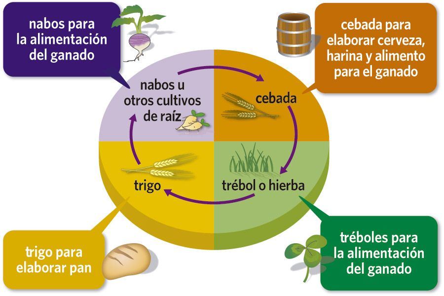

### 1.1.4 Conseqüenciès

- Aument del CR
- Emigració cap a la ciutat
- Inversió del capital en la industrial

## 1.2 Revolució Demogràfica

### 1.2.1 Situació a finals del segle XVIII

A meitat el segle XVIII la població va esperimentar un creixement real(la resta entre naixements y morts produit) exponencial; es a dir que creix molt en poc temps

### 1.2.2 Descripció

- La taxa de Natalitat va aumentar drasticament.
- La taxa de mortalitat es va reduir
- Com a conseqüència del dos punts anteriors el creixement real va a aumentar

### 1.2.3 Lloc, Data

Aquest canvi es va produir en Europa, però sobretot a Anglaterra. Va començar durant el segle XVIII i es podria dir que continua indefinidament.

### 1.2.4 Causes

- Aument del exedent agrari
- Millora de l’alimentació i la higiene
- Avanços mèdics i sanitaris
- Canalització del aigua
- Major us del Sabó

### 1.2.5 Conseqüències

- Augment de la mà d’obra
- Augment de la demanda del aliments i productes manufacturats
- Augment de les ciutats

# 2 ELS INICIS DE LA INDUSTRIALITZACIÓ

## 2.2 Proces de la industralització

Desenvolupament de les indústries: téxtil i siderúrgica

### 2.2.1 Téxtil

Com a conseqüència de l’augment de la població el primer sector en industrialitzar-se va ser el téxtil per l’augment de la població y les materies primes importades de les colònies

### 2.2.2 Siderúrgica

L’hulla un tipo de carbó va aumentar la qualitat del ferro que es va utilitzar per a els transports

## 2.3 Expansió internacional

1. Anglaterra
2. Europa
   - França
   - Bèlgica
   - Alemanya
3. EUA i Japó

Tot aixó es pot veure reflectit en aquest mapa

[figure not shown]

# 3 LA REVOLUCIÓ DELS TRANSPORTS

## 3.1 Introducció

### 3.1.1 Situació al segle XVIII

Els únics sistemes de tranports eren els tradicionals (vent, aigua i força animal)

### 3.1.2 Descripció

Al segle XIX es va comená a aplicar la maquina de vapor als medis de transports. Ja que la gent tenia la necesitat de desplazarse a una rapidesa superior.

## 3.2 Ferrorocaril

- Vagonestes de tracció animal → Locomotora a Vapor
- En 1825 es va inagurar la primera lienea de ferrocaril
- En 1830 primera línia amb passatgers
- Durant el reste del segle XIX es va perfeccionar la locomotora

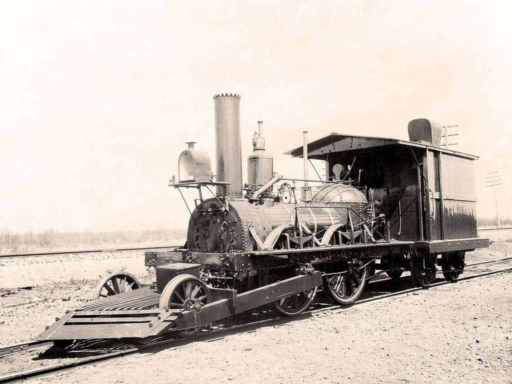

Un tren de 1830

## 3.3 Vaixell de vapor i travessies marítimes

- En 1803 es va idear la idea del vaixell de vapor
- En 1807 va fer la seva primera travessiaente Nova York i Albany (mediant el riu Hudson)
- En 1819 un vaixell va creuar el oceà atlàntic
- A mitjans del segle XIX el us del vaixell es va estendre
- A la fi del sele XIX el 67% dels vaixells eran de vapor
- Més abant s’introduira el casc de Ferro y de Hèlix, a més del canvi de grandaria
- Va ser molt utilitzat per al comerç

[figure not shown]

Un vaixell a vapor

## 3.4 L’automòbil i l’avió

- Es varen crear amb el motord’explosió
- En 1885 K. Benv va utlitzar el motiu de gasolina en els seus automòbils
- En 1903 els germans Wright van fer el primer vol amb avió

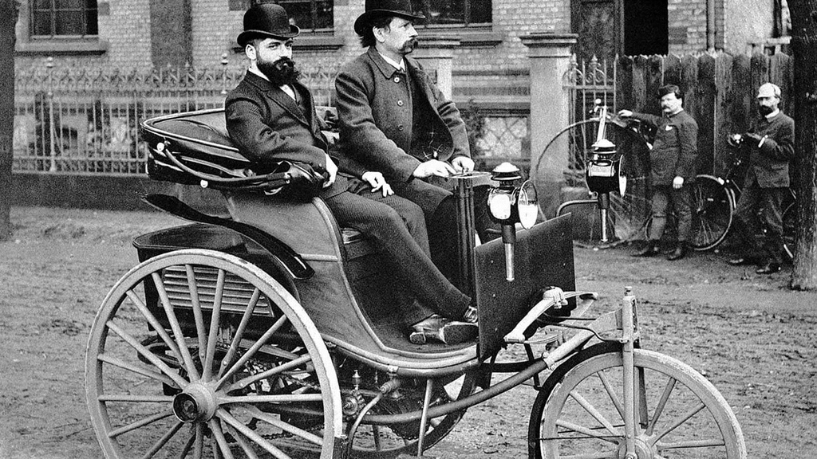

[figure not shown]

Primer avió

# 4 EL TRIOMF DEL CAPITALISME

## 4.1 Descripció

El capitalisme és un sistema econòmic que es va instaurar entre el propietaris i els inversors de les fabriques

## 4.2 Aparició

El capitalisme va apareixer durant la revolució industrial. Las idees econòmiques anavan lligades a la burgesia, es basa en la societat privada. El lliurecanvisme va substituir al proteccionisme, impulsat per Adam Smith.

[figure not shown]

### 4.2.1 LLiurecanvisme

- Comerç Internacional
- Lliure competencia
- Intervenció del estat
- Proteccionisme

## 4.3 Sistema Anterior / Sistema Industrial de Producció

### 4.3.1 Sistema Anterior (Gremis)

- Gremis, agrupació de persones del mateix ofici controlava la producció
- Els gremis tenian el su propi escalfó
  - Aprenent
    - Viu al gremi
    - No te remuneració econòmica
  - Oficial
    - Te remuneració economica
  - Mestre Artesá
    - Dirigeix el gremi
- Tot el procés o fa una persona

### 4.3.2 Sistema Industrial

- Es treballa a una fàbrica
- Producció a gran escala
- Treballador sense cap qualificació
- Tasca molt específica

## 4.4 Capitalisme financer

- Creacció de les societats anonimes
  - El capital per a una inversió provenia d’una associació de burgesos
  - Cada part de l’empresa era una acció que es venia a la borsa
- La banca va comenár a inventir

# 5 LA SOCIETAT DE CLASSES

## 5.1 Introducció

- Canvis dratics en la societat:
- Aritocràcia
- Artesans
- Burgesia ↑
- Proletariat ↑

## 5.2 Burgesia

- Propietats de mitjans de producció
  - Maquines
  - Capital
  - …
- Família va ser básica
- Matrimoni
- Mansió
- Higiene (a partir del segle XX)
- Vida Social
- Casinos
- Cafe

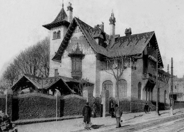

Mansió de la burgesia

## 5.3 Proletariat (Segle XIX)

- Obresrs per a les fàbriques
  - Força de treball
  - Salari
- Llarges jornades laborals
  - 14 - 16 hores
- DeshumanitzacióS
- Incorportació infantil i femenina
- Poca higiene
- Escàs temps d’oci

# 6 EL MOVIMENT OBRER

## 6.1 Què és el moviment obrer i per què va sorgir?

## 6.2 Com va sorgir l’obrerisme?

## 6.3 Què és el socialisme?

### 6.3.1 Explica els diferents tipus de pensament socialista: què proposen i com volien aconseguir els seus objectius?

## 6.4 Què és l’anarquisme, què proposa i com pretenia aconseguir els seus objectius?

## 6.5 La Internacionals obrera:

### 6.5.1 Què va ser?

### 6.5.2 Per què va sorgir? On? Quan?

### 6.5.3 A quines dificultats es va enfrontar?

# 7 L’EXPANSIÓ DE LA INDUSTRIALITZACIÓ

## 7.1 La segona revolució industrial (Què? Quan? Per què?)

## 7.2 Quines novetats va aportar la segona revolució industrial?

### 7.2.1 Noves energies

### 7.2.2 Noves indústries

### 7.2.3 Nous sistemes productius

### 7.2.4 Noves formes d’organització empresarials (Concentració empresarial què és i tipus?)

### 7.2.5 Noves potències mundials

# 8 LA INDUSTRIA A L’ACTUALITAT

## 8.1 La tercera revolució industrial (Què? Quan? Per què?)

## 8.2 Quines novetats està aportant la tercera revolució industrial?

### 8.2.1 Noves energies

### 8.2.2 Noves indústries

### 8.2.3 Nous sistemes productius

### 8.2.4 Reptes de la industria actual

### 8.2.5 Potències industrials actuals